# Practical Machine Learning Course Project

Lan Mu

5/19/2020

## Introduction

In this project, we aimed to use data from accelerometers on the belt, forearm, arm and dumbell to predict how well an activity was performed by the wearer. We used the best-performed predication model to predict 20 different test cases.

## Data Cleaning

```r
pml_training <- "https://d396qusza40orc.cloudfront.net/predmachlearn/pml-training.csv"
pml_testing <- "https://d396qusza40orc.cloudfront.net/predmachlearn/pml-testing.csv"
Train<- read.csv(pml_training, header = T, na.strings = c("", "NA"))
testing<- read.csv(pml_testing, header = T, na.strings = c("", "NA"))
set.seed(12345)
inTrain<-createDataPartition(Train$classe,p=0.7,list=FALSE)
training<-Train[inTrain,]
validation<-Train[-inTrain,]
dim(training)
```

```
## [1] 13737   160
```

The pml-training dataset further splited to training and validation dataset. At this point, training dataset had 13737 observations with 160 variables. There were too many features in the training dataset, we removed the features with majority of missing values and those contained unnecessary information.

```r
na_count <-sapply(training, function(y) sum(length(which(is.na(y)))))
train_1<-training[,na_count/dim(training)<0.05]  #Include variables with less than 5% missing value
vali_1<-validation[,na_count/dim(training)<0.05]
train_2<-train_1[,-c(1:5)] #Remove unnecessary ID information
vali_2<-vali_1[,-c(1:5)]
```

Additionally, We used PCA to recude the dimensionality of the dataset, while preserving as much statistical information as possible. We used PCA with principal component explaining 90% of the variance in the predicators.

```r
preproc<-preProcess(train_2[,-55], method = "pca", thresh = 0.9)
train<- predict(preproc,train_2[,-55]) #PCA processed training data
Vali<- predict(preproc,vali_2[,-55])  #PCA processed validation data
dim(train)
```

```
## [1] 13737    20
```

Right now, training data had 13737 observations with 20 principle components.

## Predication Model Building

In this project, we trained our dataset with decision tree,random forest, gradient boosting machine, and selected the most optimal machine learning algorthim, based on the accuracy of predication on validation dataset.

### 1)Random Forest:

```r
mod_rf<-train(x=train,y=train_2$classe,method="rf")
pred_rf<-predict(mod_rf,Vali)
rf_acc<-confusionMatrix(pred_rf,vali_2$classe)$overall["Accuracy"]
```

The random forest performed quite well, acheving 0.9751912 accuracy on predication of validation dataset.

### 2)Gradient Boosting Machine

```r
mod_gbm<-train(x=train,y=train_2$classe,method="gbm",verbose=FALSE)
pred_gbm<-predict(mod_gbm,Vali)
gbm_acc<-confusionMatrix(pred_gbm,vali_2$classe)$overall["Accuracy"]
```

GBM performed worse than random forest did, with only 0.7986406 accuracy.

### 3)Decision Tree

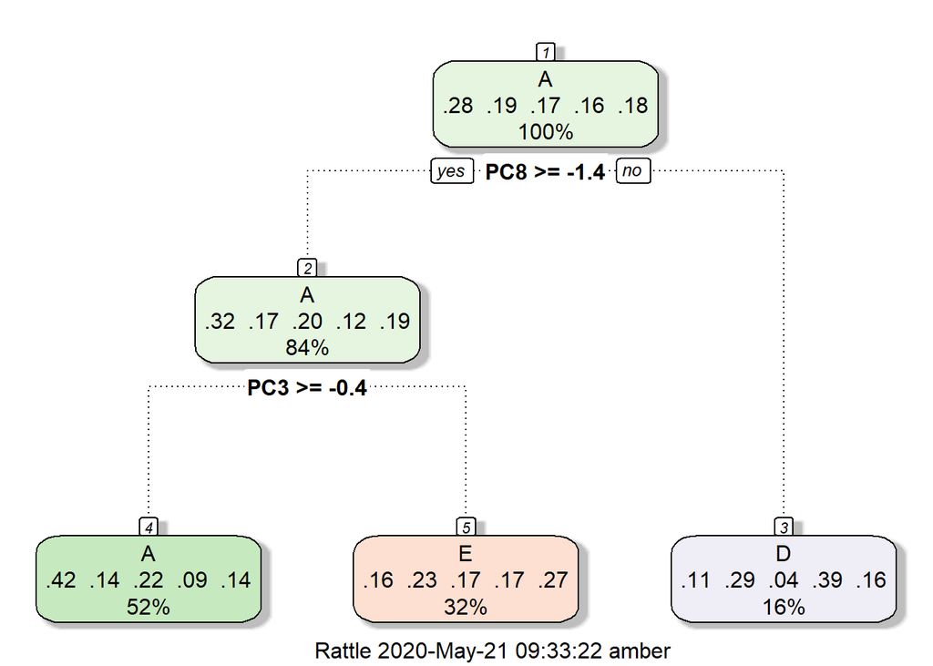

```r
mod_dt<-train(x=train,y=train_2$classe,method="rpart")
fancyRpartPlot(mod_dt$finalModel)
```

```r
pred_dt<-predict(mod_dt,Vali)
dt_acc<-confusionMatrix(pred_dt,vali_2$classe)$overall["Accuracy"]
```

## Predication on Test data

```r
test_1<-testing[,na_count/dim(training)<0.05]
test_2<-test_1[,-c(1:5)]
test<- predict(preproc,test_2[,-55])
test<-rbind(Vali[1,],test)
test<-test[-1,] #Used to resolve error: Type of predicators in new data do not match that of training data
predict(mod_rf,test)
```

```
##  [1] B A B A A E D B A A B C B A E E A B B B
## Levels: A B C D E
```